# Statistics 2 Topic 2

Author

Minerva Mukhopadhyay

## Statistical Inference: Point Estimation

- We learn some desirable properties of the *estimators*.

## (I) Key Takeaways

Let $X1,…,Xn$ be a random sample from some population characterized by $Fθ$ (i.e., $X1,…,Xn$ are *iid* samples from $Fθ$), and we are interested in estimating a function of $θ$, say $ψ=ψ(θ)$.

**Definition****(Statistic)**: Any function of the random samples $X1,…,Xn$ is called a statistic.

**Definition****(Estimator)**: Suppose the statistic $T(X)$ is used to estimate $ψ=ψ(θ)$, then $T(X)$ is called an *estimator* of $ψ(θ)$.

For a particular realization of $X1,…,Xn$, say, $x1,…,xn$, the value of $T(x)$ is called an *estimate* of $ψ(θ)$.

**Note:** Like the random sample, a statistic (in particular, an estimator) $T(X)$ is also a random variable. The distribution of $T(X)$ is called the *sampling distribution* of $T(X)$.

**Example**: Let $X1,…,Xn$ be a random sample of size $n$ from $Binomial(m,θ)$ distribution. Consider three estimators of $θ$ as:

$$T1(X)=1mX¯n,T2(X)=Sn2m+X¯n2m2,andT3(X)=1mX1.$$

We can obtain the sampling distribution of these statistics analytically, as well as using simulation.

- For $m=20$ and different choices of $θ$, the sampling distribution of $T1(X)$ (calculated based on $n=15$ random samples) is described in the following histograms.

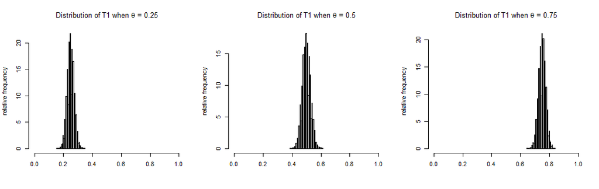

- For $m=20$ and different choices of $θ$, the sampling distribution of $T2(X)$ (calculated based on $n=15$ random samples) is described in the following histograms.

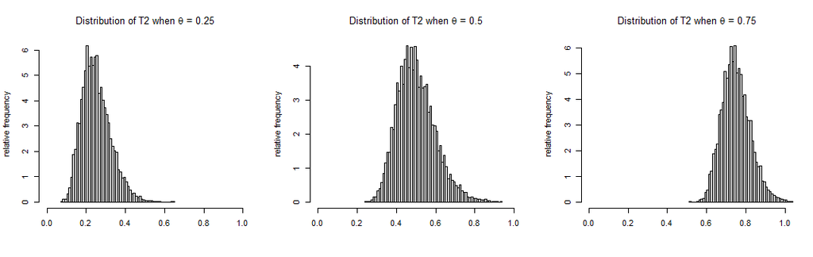

- For $m=20$ and different choices of $θ$, the sampling distribution of $T3(X)$ (calculated based on $n=15$ random samples) is described in the following histograms.

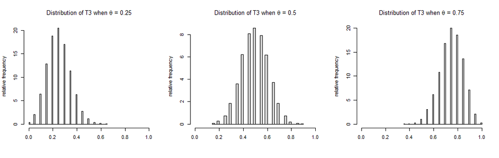

**Definition** **(Unbiasness)** Let $T(X)$ be an estimator of $ψ(θ)$. Then the bias in estimating $ψ(θ)$ by $T(X)$ is defined as

$$BT,n(ψ(θ))=Eθ(T(X))−ψ(θ).$$

An estimator $T(X)$ is called *unbiased* if $BT,n(ψ(θ))=0$ for all $θ$.

- If $BT,n(ψ(θ))>0$ (or, $<0$) then $T(X)$ tends to overestimate (or, underestimates) $ψ(θ)$.
- Among the unbiased estimators, one would like to choose that estimator which has smaller variance.

**Definition** **(Relative Efficiency)** Let $T1(X)$ and $T2(X)$ be two unbiased estimators of $ψ(θ)$. Then the relative efficiency of $T1$ and $T2$ is

$$RET1,T2(ψ(θ))=varθ(T1)varθ(T2).$$

- If $RET1,T2(ψ(θ))<1$ (or, $>1$) then the estimator $T1$ is preferred (or, not preferred) over $T2$.

### What is the minimum possible value of the variance of an unbiased estimator?

- If the underlying distribution $Fθ$ satisfies some *regularity conditions* then it is possible to obtain an achievable lowerbound of the variance of any estimator $T(X)$ of $ψ(θ)$.
- Define $Eθ{T(X)}=ψ(θ)$, $ψ′(θ)=∂∂θψ(θ)$ and $I(θ)=Eθ[{∂∂θlogfX1(X1;θ)}2]$.
- If $0<I(θ)<∞$, then $T(X)$ satisfies

$$varθ{T(X)}≥[ψ′(θ)]2nI(θ).$$

- The quantity in the RHS of the above expression is called the *Cramer-Rao Lower bound (CRLB)*.
- $I(θ)$ is called the *Fisher information* of $θ$ based on one sample. $nI(θ)$ is the Fisher information of $θ$ based on $n$ *iid* samples.
- For the case where $ψ(θ)=θ$ and $T(X)$ is an unbiased estimator of $θ$, CRLB reduces to $[nI(θ)]−1$.
- If for an estimator the CRLB is achieved, then it is the best unbiased estimator.

**Example** (continued): In the binomial example (stated above) it can be shown that $T1(X)$ satisfies the CRLB.

**Definition** **(Efficient estimator)** An unbiased estimator of $ψ(θ)$ that attains the CRLB is called an *efficient estimator*.